# Script to determine the input parameters for generating the REF_APP_FluxConversion reference file

This script can be used to generate the plots presented in the following document: https://redmine.isdc.unige.ch/projects/cheops/wiki/Flux_Conversion

In addition to generating the plots, the script performs a fit to the empirical ratio (observed flux / predited flux) vs effective temperature. The parameters from this fit are used as input to the runFluxConversion executable in the CHEOPSim SOC software package, used to generate the REF_APP_FluxConversion reference file.

```python
%matplotlib inline
import matplotlib.pyplot as plt
import numpy as np
from astropy.io import fits
import matplotlib as mpl
mpl.style.use('classic')
mpl.rcParams['figure.facecolor'] = '1.'
mpl.rcParams['axes.formatter.useoffset'] = False
from copy import copy, deepcopy
import csv
from numpy.polynomial.polynomial import polyfit
```

Define the path to CHEOPSim/resources, which can be checkout out from svn here:

https://svn.isdc.unige.ch/svn-cheops/06_cheopsim/software/CHEOPSim/tags/current/resources/

```python
CHEOPSim_resources_path = '/Users/futyand/CHEOPS/cheops_svn_v6/CHEOPSim/resources/'
```

Read in the QE and optical throughput files and calculate the CHEOPS passband (global throughput)

```python
hdulist = fits.open(CHEOPSim_resources_path+'CH_TU2020-01-29T00-00-00_REF_APP_QE_V0101.fits')
wavelength = hdulist[1].data.field(0)
qe = hdulist[1].data.field(1)
hdulist.close()

hdulist = fits.open(CHEOPSim_resources_path+'CH_TU2018-01-01T00-00-00_REF_APP_Throughput-BeginOfLife_V0100.fits')
throughput = hdulist[1].data.field(1)
hdulist.close()

globalThroughput = throughput*qe
```

Read in the V-band and Gaia pass band

```python
transmission_Vband = [0,0.03,0.084,0.163,0.301,0.458,0.630,0.780,0.895,0.967,0.997,1.,0.988,0.958,0.919,0.877,0.819,0.765,0.711,0.657,0.602,0.545,0.488,0.434,0.386,0.331,0.289,0.25,0.214,0.181,0.151,0.12,0.093,0.069,0.051,0.036,0.027,0.021,0.018,0.016,0.014,0.012,0.011,0.010,0.009,0.008,0.007,0.006,0.005,0.004,0.003,0.002,0.001,0.]
wavelength_Vband = np.arange(475,745,5).tolist()

f = open(CHEOPSim_resources_path+'GaiaDR2_RevisedPassbands.dat', 'r')
lines = f.readlines()
f.close()
gaia_data = []
for line in lines:
    p = line.split()
    gaia_data.append(p)
gaia_data_arr = np.asfarray(gaia_data)
gaia_wavelength = gaia_data_arr[:3197,0]
gaia_passband = gaia_data_arr[:3197,1]
```

Plot the various passbands to compare their shapes

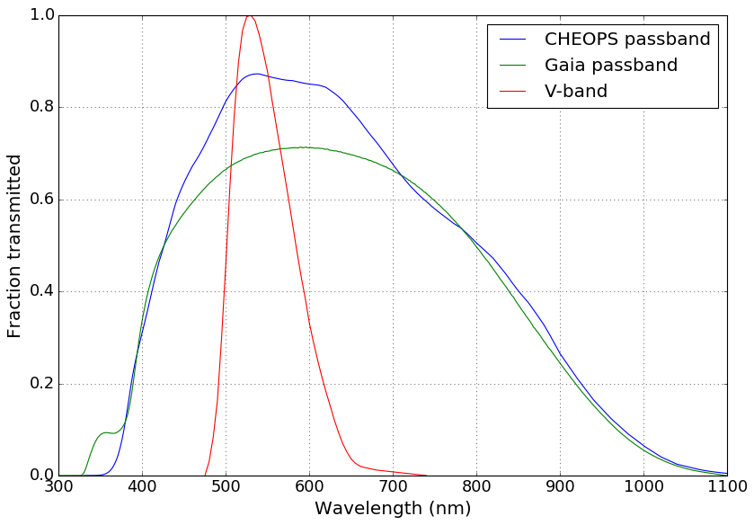

```python
plt.figure(figsize=(12,8))
ax = plt.subplot(1,1,1)
plt.plot(wavelength,globalThroughput,label='CHEOPS passband')
plt.plot(gaia_wavelength,gaia_passband,label='Gaia passband')
plt.plot(wavelength_Vband,transmission_Vband,label='V-band')
plt.ylabel('Fraction transmitted',size=18)
plt.xlabel('Wavelength (nm)',size=18)
plt.setp(ax.get_xticklabels(), fontsize=16)
plt.setp(ax.get_yticklabels(), fontsize=16)
plt.ylim(0,1)
plt.grid()
legend = plt.legend(loc='upper right', shadow=False, fontsize=18)
```

An initial predicted flux (before empirical correction for observed/preducted vs TEff) is determined by generating an uncorrected version of REF_APP_FluxConversion, by executing runFluxConversion with the following non-default settings in runFluxConversion.xml:

CH_TU2020-01-29T00-00-00_REF_APP_FluxConversion_V0104_nofit.fits:

- fitIntercept = 1.
- fitSlope = 0.

The above configuration models stellar spectra using PHOENIX SEDs for TEff<7200K, and black body spectra for higher TEffs. For comparison, a version using black body spectra for all effective temperatures is generated by running with the following non-default settings:

CH_TU2020-01-29T00-00-00_REF_APP_FluxConversion_V0104_nofit_blackbody.fits

- SEDFilename = null
- blackBodyOffset = 0.
- fitIntercept = 1.
- fitSlope = 0.

It is the comparison of value of (CHEOPS mag - Gaia mag) at TEff=7200K from these two cases which provides the default value for blackBodyOffset in runFluxConversion.xml

```
Offset between Phoenix SED and BB derived curves @ 7200K = -0.00479508808386813
```

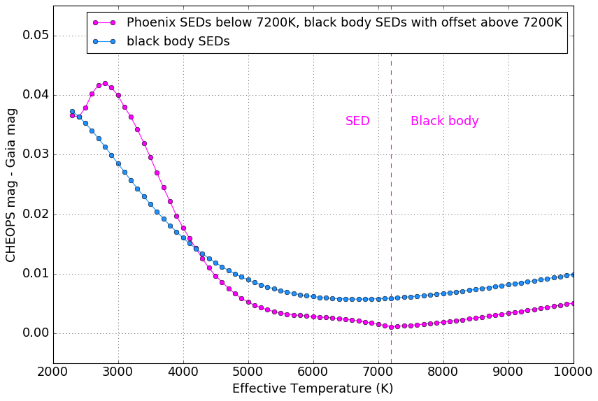

```python
hdulist = fits.open(CHEOPSim_resources_path+'CH_TU2020-01-29T00-00-00_REF_APP_FluxConversion_V0104_nofit.fits')
TEff = hdulist[1].data.field(0)
CmagMinusGmag = hdulist[1].data.field(1)
F0_X_aperture30 = hdulist[1].header['F0_X']
hdulist.close()

hdulist = fits.open(CHEOPSim_resources_path+'CH_TU2020-01-29T00-00-00_REF_APP_FluxConversion_V0104_nofit_blackbody.fits')
CmagMinusGmag_bb = hdulist[1].data.field(1)
hdulist.close()

for i in range(len(TEff)):
    if TEff[i]==7200:
        iTEff_7200 = i
        break
print('Offset between Phoenix SED and BB derived curves @ 7200K =',CmagMinusGmag[iTEff_7200]-CmagMinusGmag_bb[iTEff_7200])

plt.figure(figsize=(12,8))
ax = plt.subplot(1,1,1)
plt.plot(TEff,CmagMinusGmag,label='Phoenix SEDs below 7200K, black body SEDs with offset above 7200K',marker='o',color='magenta')
plt.plot(TEff,CmagMinusGmag_bb,label='black body SEDs',marker='o',color='dodgerblue')
plt.xlabel('Effective Temperature (K)',fontsize=16)
plt.ylabel('CHEOPS mag - Gaia mag',fontsize=16)
plt.setp(ax.get_xticklabels(), fontsize=16)
plt.setp(ax.get_yticklabels(), fontsize=16)
plt.xlim(2000,10000)
plt.ylim(-0.005,.055)
plt.axvline(7200,linestyle='dashed',color='magenta')
plt.text(7500,0.035,'Black body',color='magenta',fontsize=16)
plt.text(6500,0.035,'SED',color='magenta',fontsize=16)
plt.grid(1)
legend = plt.legend(loc='upper right', fontsize=16)
plt.show()
```

Read in the measured fluxes, effective temperatures and Gaia magnitudes for 102 non-variable stars observed with CHEOPS during the in orbit commissioning phase B, and sort them in order of increasing effective temperature

```python
hdulist = fits.open(CHEOPSim_resources_path+'IOC-B_TU2020-03-02T16-37-31_ioc_report_statistics_psf_phase_B_v1.0_Gmag_clean.fits')
TEff_Andrea_unsorted = hdulist[1].data.field(6)
measured_Andrea_unsorted = hdulist[1].data.field(20)
Gmag_Andrea_unsorted = hdulist[1].data.field(5)
hdulist.close()

#Generate sorted lists, ordered by effective temperature
mytuples = []
TEff_Andrea = []
measured_Andrea = []
Gmag_Andrea = []
for i in range(len(TEff_Andrea_unsorted)):
    if TEff_Andrea_unsorted[i] != 6003: #Exclude outlier HD83105
        mytuple = (TEff_Andrea_unsorted[i],measured_Andrea_unsorted[i],Gmag_Andrea_unsorted[i])
        mytuples.append(mytuple)
mytuples.sort(key=lambda tup: tup[0])
for mytuple in mytuples:
    TEff_Andrea.append(mytuple[0])
    measured_Andrea.append(mytuple[1])
    Gmag_Andrea.append(mytuple[2])
```

Obtain (CHEOPS mag - Gaia mag) for each star by interpolating between the points in CH_TU2020-01-29T00-00-00_REF_APP_FluxConversion_V0104_nofit.fits to the effective temperature of the star.

```python
CminusG_Andrea = []
for star in range(len(TEff_Andrea)):
    CminusG = 0
    for i in range(len(TEff)):
        if TEff[i] > TEff_Andrea[star]:
            mu = (TEff_Andrea[star]-TEff[i-1])/(TEff[i]-TEff[i-1])
            CminusG = CmagMinusGmag[i-1]*(1.-mu)+CmagMinusGmag[i]*mu
            break
    CminusG_Andrea.append(CminusG)
```

Calculate the predicted flux for each star as F0_X *10^(-0.4*CHEOPSmag) where F0_X is defined in https://redmine.isdc.unige.ch/projects/cheops/wiki/Flux_Conversion and has been read as a header keyword of CH_TU2020-01-29T00-00-00_REF_APP_FluxConversion_V0104_nofit.fits

```python
predicted_SOC = []
for i in range(len(TEff_Andrea)):
    predicted_SOC.append(F0_X_aperture30 * 10**(-0.4*(Gmag_Andrea[i] + CminusG_Andrea[i])))
ratio = np.asfarray(measured_Andrea) / np.asfarray(predicted_SOC)
```

Perform the fit to (observed flux / preducted flux) vs effective temperature. The fit parameters are used as default parameters in runFluxConversion.xml, used to generate CH_TU2020-01-29T00-00-00_REF_APP_FluxConversion_V0104.fits

```
Fit result: b = 0.9460354317895686 m = -2.00738331549484e-06
Fit value at TEff of Vega:  0.9267645519608182
```

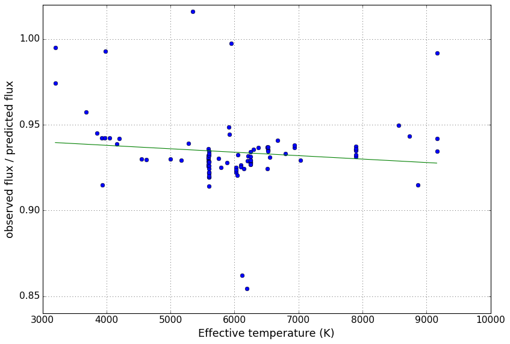

```python
plt.figure(figsize=(12,8))
ax = plt.subplot(1,1,1)

b, m = polyfit(TEff_Andrea, ratio, 1)
teff_fit = np.arange(np.min(TEff_Andrea),np.max(TEff_Andrea),10.)
fitval = b + m*teff_fit
fitval_vega = b + m*9600
print('Fit result: b =',b,'m =',m)
print('Fit value at TEff of Vega: ',fitval_vega)

plt.plot(TEff_Andrea,ratio,'o')
plt.ylabel('observed flux / predicted flux',size=16)
plt.xlabel('Effective temperature (K)',size=16)
plt.setp(ax.get_xticklabels(), fontsize=14)
plt.setp(ax.get_yticklabels(), fontsize=14)
ax.plot(teff_fit, fitval)
#plt.ylim(0.9,1.1)
plt.grid()
```

Apply the correction defined by the fit and re-plot observed/predicted vs effective temperature. After correction, the plot has no slope and has mean value 1.

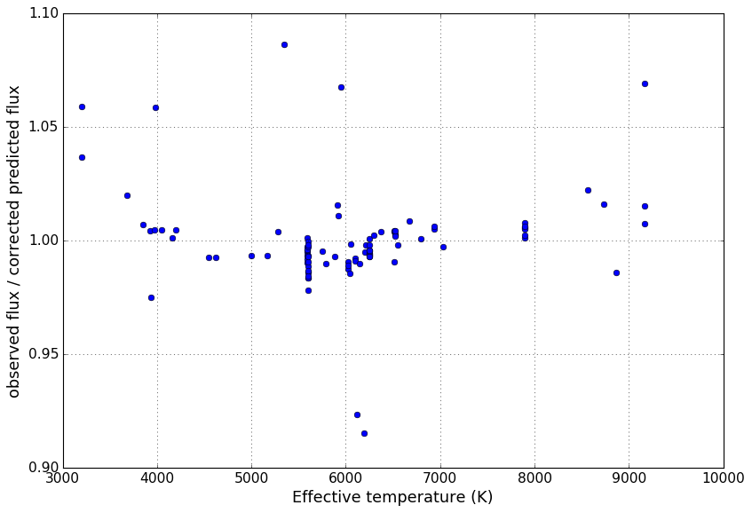

```python
predicted_SOC_corrected = []
for i in range(len(TEff_Andrea)):
    predicted_SOC_corrected.append(F0_X_aperture30 * (10**(-0.4*(Gmag_Andrea[i] + CminusG_Andrea[i] - 2.5*np.log10(b + m*TEff_Andrea[i])))))
ratio_corrected = np.asfarray(measured_Andrea) / np.asfarray(predicted_SOC_corrected)

plt.figure(figsize=(12,8))
ax = plt.subplot(1,1,1)
plt.plot(TEff_Andrea,ratio_corrected,'o')
plt.ylabel('observed flux / corrected predicted flux',size=16)
plt.xlabel('Effective temperature (K)',size=16)
plt.setp(ax.get_xticklabels(), fontsize=14)
plt.setp(ax.get_yticklabels(), fontsize=14)
#plt.ylim(0.9,1.1)
plt.grid()
```

The final version of the FluxConversion reference file, CH_TU2020-01-29T00-00-00_REF_APP_FluxConversion_V0104.fits, is generated by executing runFluxConversion with default settings, which include the fit parameters calculated in the previous step.

The following is a cross check to confirm that CH_TU2020-01-29T00-00-00_REF_APP_FluxConversion_V0104.fits has been generated correctly, by calculating the predicted flux for each of the IOC-B stars using the data contained within the file. The plot should match the corrected plot from the previous step.

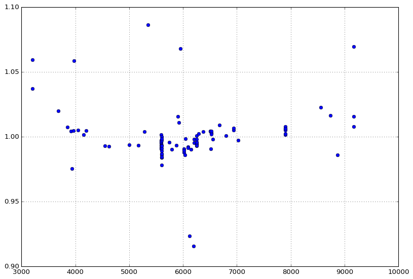

```python
hdulist = fits.open(CHEOPSim_resources_path+'CH_TU2020-01-29T00-00-00_REF_APP_FluxConversion_V0104.fits')
CmagMinusGmag_linearFit = hdulist[1].data.field(1)
F0_X_aperture30_scaled = hdulist[1].header['F0_X']
hdulist.close()

CminusG_linearFit = []
for star in range(len(TEff_Andrea)):
    CminusG = 0
    for i in range(len(TEff)):
        if TEff[i] > TEff_Andrea[star]:
            mu = (TEff_Andrea[star]-TEff[i-1])/(TEff[i]-TEff[i-1])
            CminusG = CmagMinusGmag_linearFit[i-1]*(1.-mu)+CmagMinusGmag_linearFit[i]*mu
            break
    CminusG_linearFit.append(CminusG)

predicted_scaledWithLinearFit = []
for i in range(len(TEff_Andrea)):
    predicted_scaledWithLinearFit.append(F0_X_aperture30_scaled * 10**(-0.4*(Gmag_Andrea[i] + CminusG_linearFit[i])))

ratio_scaledWithLinearFit = np.asfarray(measured_Andrea) / np.asfarray(predicted_scaledWithLinearFit)

plt.figure(figsize=(12,8))
ax = plt.subplot(1,1,1)
plt.plot(TEff_Andrea,ratio_scaledWithLinearFit,'o')
plt.ylim(0.9,1.1)
plt.grid()
```

Plot the contents of CH_TU2020-01-29T00-00-00_REF_APP_FluxConversion_V0104.fits

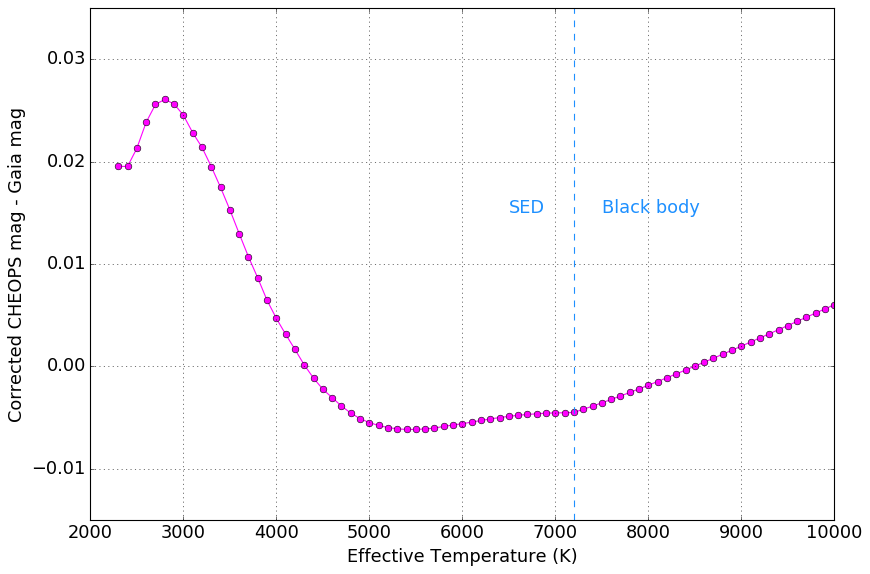

```python
plt.figure(figsize=(12,8))
ax = plt.subplot(1,1,1)
plt.plot(TEff,CmagMinusGmag_linearFit,label='Phoenix SEDs below 7200K, black body above 7200K',marker='o',color='magenta')
plt.xlabel('Effective Temperature (K)',fontsize=16)
plt.ylabel('Corrected CHEOPS mag - Gaia mag',fontsize=16)
plt.setp(ax.get_xticklabels(), fontsize=16)
plt.setp(ax.get_yticklabels(), fontsize=16)
plt.xlim(2000,10000)
plt.ylim(-.015,.035)
plt.axvline(7200,linestyle='dashed',color='dodgerblue')
plt.text(7500,0.015,'Black body',color='dodgerblue',fontsize=16)
plt.text(6500,0.015,'SED',color='dodgerblue',fontsize=16)
plt.grid(1)
plt.show()
```